# Basics of Probability Theory Part 1

2022-09-01

# Probability vs Statistics

**Probability**

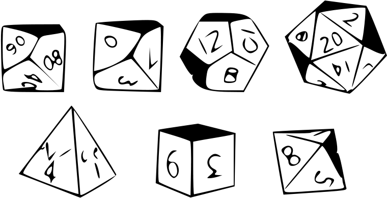

- A measure on how likely an event occurs
- Computing probabilities have rules
- Logical reasoning
- One answer

**Statistics**

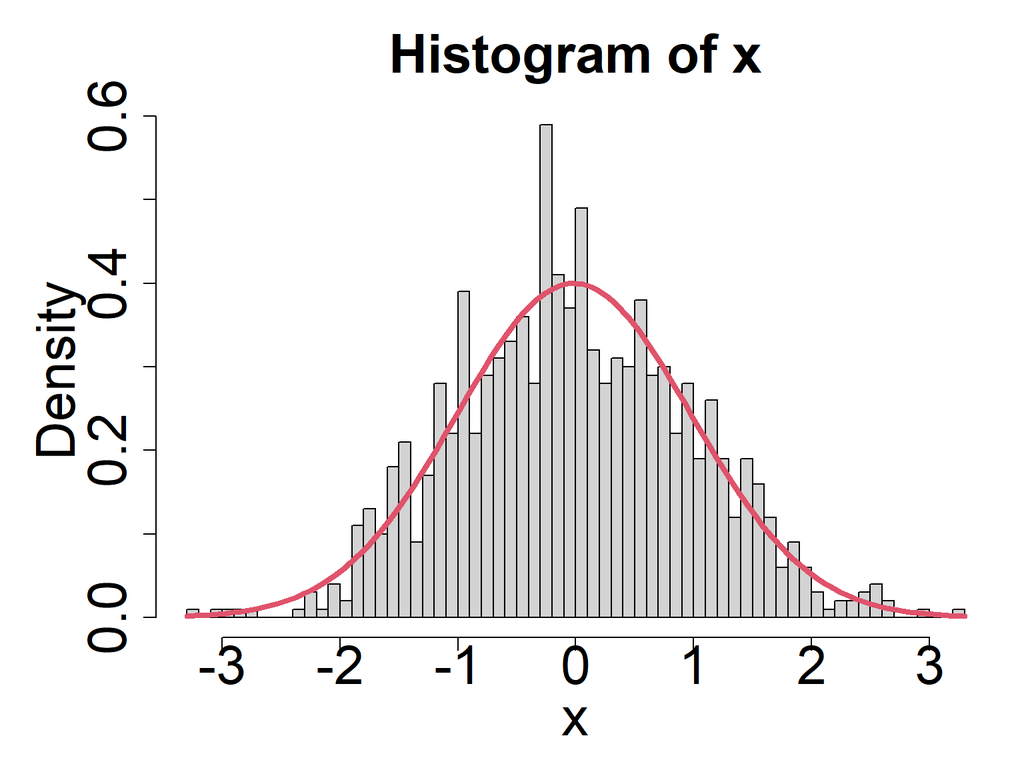

- Methods on answering how likely it is that a claim is true
- It’s an Art
- Data-driven approach to write conclusions
- Multiple ways to solve problems

# Probability Terminologies

**[PSDR] Definition 2.1.**

Terminology for statistical experiments:

- An **experiment** is a process that produces an observation.
- An **outcome** is a possible observation.
- The set of all possible outcomes is called the **sample space**.
- An **event** is a subset of the sample space.
- A **trial** is a single running of an experiment.

# Set Theory Basics

**[PSDR] Definition 2.5**

Let $A$ and $B$ be events in a sample space $S$.

1. $A \cap B$ is the set of outcomes that are in both $A$ and $B$.
2. $A \cup B$ is the set of outcomes that are in either $A$ or $B$ (or both).
3. $A − B$ is the set of outcomes that are in $A$ and not in $B$.
4. The complement of $A$ is $\bar{A} = S - A$. So, $\overline{A}$ is the set of all outcomes that are not in $A$.
5. The symbol $\emptyset$ is the empty set, the set with no outcomes.
6. $A$ and $B$ are disjoint if $A \cap B = \emptyset$.
7. $A$ is a subset of $B$, written $A \subset B$, if every element of $A$ is also an element of $B$.

# Probability Axioms Part 1

**[PSDR] Definition 2.7**

# Probability Axioms Part 2

**[PSDR] Theorem 2.1**

# Independence

**[PSDR] Definition 2.20**

Two events are said to be *independent* if knowledge that one event occurs does not give any probabilistic information as to whether the other event occurs. Formally, we say that $A$ and $B$ are independent if $P(A \cap B) = P(A)P(B)$.

Events $A$ and $B$ are said to be dependent if they are not independent.

# Mini-Activity

Mini-Assignment: Probability Theory Basics Part 1

Back to Tentative Topics Schedule.